# Assignment 3

hetvi9802

2025-10-06

```r
suppressPackageStartupMessages({
  library(seqinr)   # read.fasta, translate, s2c, count helpers
  library(R.utils)  # gunzip
  library(dplyr)
  library(ggplot2)
})
```

```r
###1 Download coding DNA sequences (CDS)
# I downloaded the complete coding DNA sequence (CDS) FASTA files for Escherichia coli K-12 MG1655 and Bifidobacteriaceae WP012 from the Ensembl Bacteria database. The compressed files were decompressed using R.utils:gunzip(), and sequences were imported into R with read.fasta() from the seqinr package. The number of CDS was determined by counting the total elements in each FASTA object using length() and summarised in a two-row data frame.
URL_ecoli <- "https://ftp.ensemblgenomes.ebi.ac.uk/pub/bacteria/release-62/fasta/bacteria_0_collection/escherichia_coli_str_k_12_substr_mg1655_gca_000005845/cds/Escherichia_coli_str_k_12_substr_mg1655_gca_000005845.ASM584v2.cds.all.fa.gz"

URL_bifido <- "https://ftp.ensemblgenomes.ebi.ac.uk/pub/bacteria/release-62/fasta/bacteria_63_collection/bifidobacteriaceae_bacterium_wp012_gca_003585625/cds/Bifidobacteriaceae_bacterium_wp012_gca_003585625.ASM358562v1.cds.all.fa.gz"

# Download and unzip
if (!file.exists("ecoli_cds.fa")) {
  download.file(URL_ecoli, destfile = "ecoli_cds.fa.gz", quiet = TRUE, mode = "wb")
  R.utils::gunzip("ecoli_cds.fa.gz", overwrite = TRUE)
}
if (!file.exists("bifido_cds.fa")) {
  download.file(URL_bifido, destfile = "bifido_cds.fa.gz", quiet = TRUE, mode = "wb")
  R.utils::gunzip("bifido_cds.fa.gz", overwrite = TRUE)
}

stopifnot(file.exists("ecoli_cds.fa"), file.exists("bifido_cds.fa"))
```

```r
cds_ecoli <- read.fasta("ecoli_cds.fa")
cds_bifido <- read.fasta("bifido_cds.fa")
```

```r
num_ecoli_cds <- length(cds_ecoli)
num_bifido_cds <- length(cds_bifido)

cds_count_table <- data.frame(
  Organism = c("E. coli MG1655", "Bifidobacteriaceae WP012"),
  CDS_Count = c(num_ecoli_cds, num_bifido_cds)
)
cds_count_table
```

```
##                   Organism CDS_Count
## 1           E. coli MG1655      4239
## 2 Bifidobacteriaceae WP012      1191
```

Answer: E. coli has a larger number of coding sequences compared with Bifidobacteriaceae, reflecting its relatively larger genome size and greater gene content. This suggests E. coli may have more diverse metabolic and regulatory capabilities.

```r
###2 Total coding DNA length
# For each imported CDS set, I calculated the sequence lengths using the summary() function and extracted the first column (length in base pairs). The total coding DNA was then obtained by summing all lengths with sum(). These totals were displayed in a table to compare total coding DNA between E. coli and Bifidobacteriaceae.
len_ecoli <- as.numeric(summary(cds_ecoli)[, 1])
len_bifido <- as.numeric(summary(cds_bifido)[, 1])

coding_len_table <- data.frame(
  Organism = c("E. coli MG1655", "Bifidobacteriaceae WP012"),
  Total_Coding_DNA_bp = c(sum(len_ecoli), sum(len_bifido))
)
coding_len_table
```

```
##                   Organism Total_Coding_DNA_bp
## 1           E. coli MG1655             3978528
## 2 Bifidobacteriaceae WP012             1116192
```

Answer: The total coding DNA is higher in E. coli than in Bifidobacteriaceae, consistent with its higher CDS count. This indicates that E. coli has both more genes and longer coding sequences on average, suggesting more complex protein-coding potential.

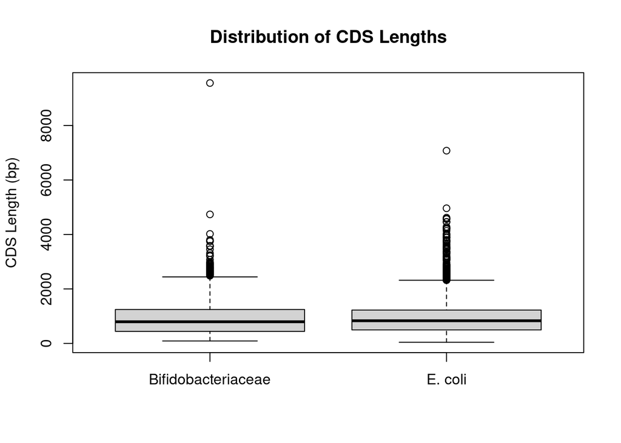

```r
###3 CDS Length Statistics + Boxplot
boxplot(len_bifido, len_ecoli,
        names = c("Bifidobacteriaceae", "E. coli"),
        ylab = "CDS Length (bp)",
        main = "Distribution of CDS Lengths")
```

```r
length_stats <- data.frame(
  Organism = c("Bifidobacteriaceae WP012", "E. coli MG1655"),
  Mean_CDS_Length = c(mean(len_bifido), mean(len_ecoli)),
  Median_CDS_Length = c(median(len_bifido), median(len_ecoli))
)
length_stats
```

```
##                   Organism Mean_CDS_Length Median_CDS_Length
## 1 Bifidobacteriaceae WP012        937.1889               795
## 2           E. coli MG1655        938.5534               831
```

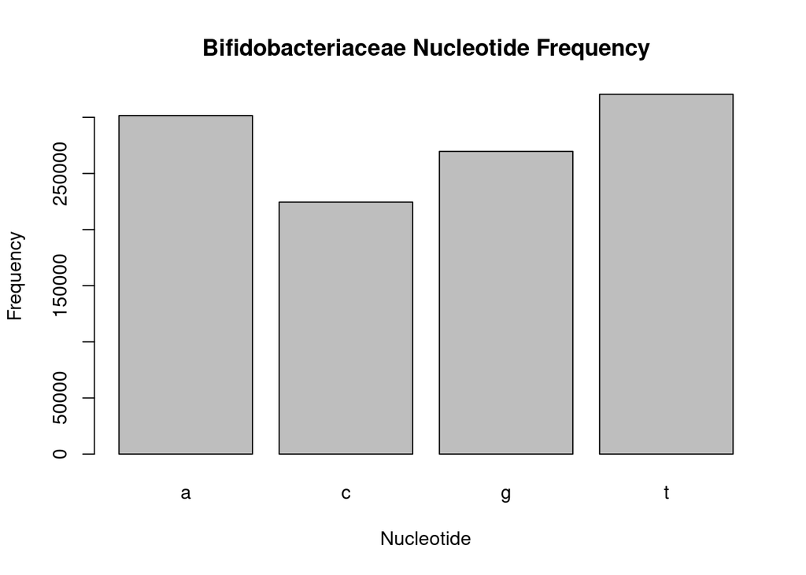

```r
###4 Nucleotide & Amino Acid Composition
# I calculated nucleotide frequencies across all coding sequences (CDS) for both organisms using table(unlist(cds_ecoli)) and table(unlist(cds_bifido)), and visualised these counts with bar plots to show the proportions of A, T, G, and C nucleotides in each genome’s coding regions. Each CDS was then translated into protein sequences using the bacterial genetic code (numcode = 11) via the translate() function from seqinr, and stop codons were removed. Amino-acid frequencies were calculated with table(unlist(prot_ecoli)) and table(unlist(prot_bifido)), and bar plots were generated to compare amino-acid usage patterns between the two organisms.
barplot(table(unlist(cds_bifido)),
        main = "Bifidobacteriaceae Nucleotide Frequency",
        xlab = "Nucleotide", ylab = "Frequency")
```

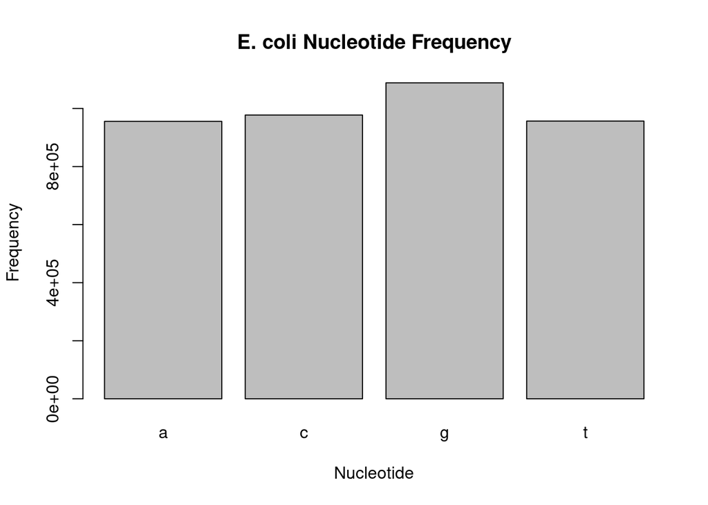

```r
barplot(table(unlist(cds_ecoli)),
        main = "E. coli Nucleotide Frequency",
        xlab = "Nucleotide", ylab = "Frequency")
```

```r
# Translate to proteins (bacterial code = 11)
prot_bifido <- lapply(cds_bifido, function(x) translate(x, numcode = 11))
prot_ecoli  <- lapply(cds_ecoli,  function(x) translate(x, numcode = 11))
```

```r
# Remove stop codons
prot_bifido <- lapply(prot_bifido, function(v) v[v != "*"])
prot_ecoli  <- lapply(prot_ecoli,  function(v) v[v != "*"])
```

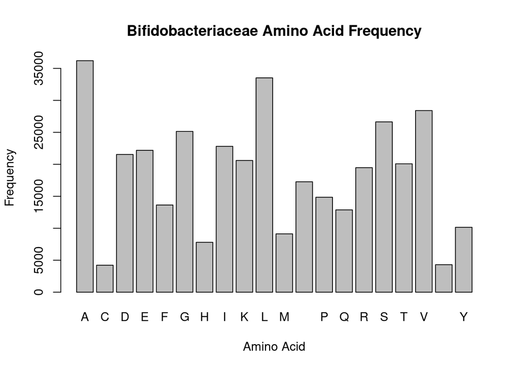

```r
# Amino acid frequency plots
barplot(table(unlist(prot_bifido)),
        main = "Bifidobacteriaceae Amino Acid Frequency",
        xlab = "Amino Acid", ylab = "Frequency")
```

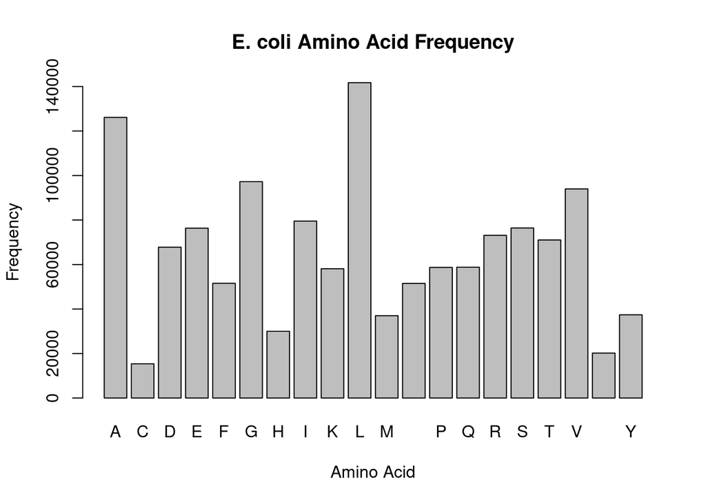

```r
barplot(table(unlist(prot_ecoli)),
        main = "E. coli Amino Acid Frequency",
        xlab = "Amino Acid", ylab = "Frequency")
```

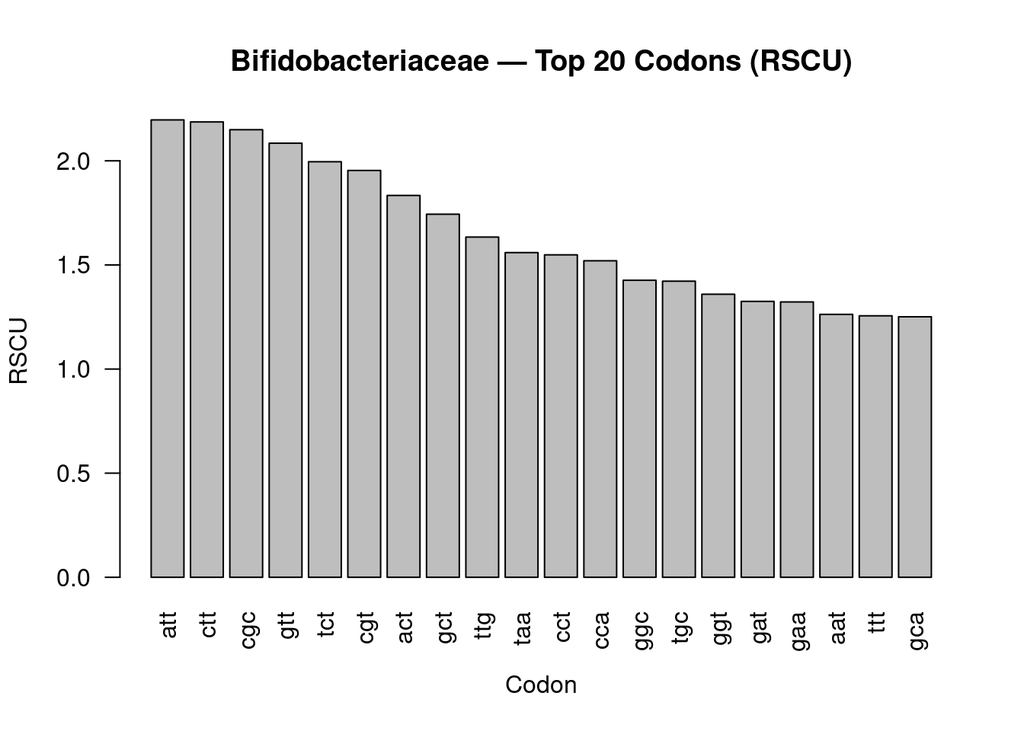

```r
###5 Codon Usage & Bias (RSCU)
# I used the seqinr function uco() to compute codon usage counts and relative synonymous codon usage (RSCU) values for all coding sequences. The top 20 codons with the highest RSCU values were identified and visualised using bar plots for each organism. This allowed comparison of codon bias and identification of preferred codons related to GC content and translational efficiency.
codon_usage_bifido_counts <- uco(unlist(cds_bifido), index = "eff")
codon_usage_ecoli_counts  <- uco(unlist(cds_ecoli),  index = "eff")

rscu_bifido <- uco(unlist(cds_bifido), index = "rscu")
rscu_ecoli  <- uco(unlist(cds_ecoli),  index = "rscu")

barplot(sort(rscu_bifido, decreasing = TRUE)[1:20],
        las = 2, main = "Bifidobacteriaceae — Top 20 Codons (RSCU)",
        xlab = "Codon", ylab = "RSCU")
```

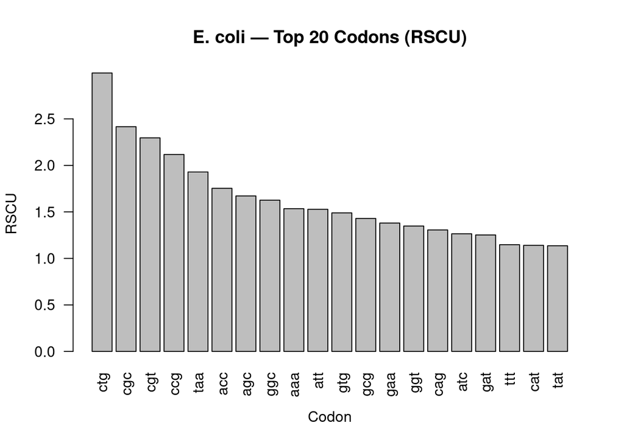

```r
barplot(sort(rscu_ecoli, decreasing = TRUE)[1:20],
        las = 2, main = "E. coli — Top 20 Codons (RSCU)",
        xlab = "Codon", ylab = "RSCU")
```

Answer: E. coli and Bifidobacteriaceae show differences in the frequency of certain amino acids. For example, one organism may have more alanine and glycine residues, while the other is enriched in leucine or valine. These differences are partly due to underlying codon usage biases and GC content, and partly due to species-specific protein composition and functional adaptations.

```r
# Remove stop codons "*" and flatten sequences
prot_bifido <- lapply(prot_bifido, function(v) v[v != "*"])
prot_ecoli  <- lapply(prot_ecoli,  function(v) v[v != "*"])
prots_bifido <- unlist(prot_bifido)
prots_ecoli  <- unlist(prot_ecoli)

# Define standard amino acid alphabet
AA <- strsplit("ACDEFGHIKLMNPQRSTVWY", "")[[1]]

###6 Helper to count k-mers
# I defined a helper function aa_kmer_freq() to count amino-acid k-mers of length 3, 4, and 5 using seqinr::count(). The function analyze_k() was applied to the translated protein sequences of Bifidobacteriaceae and E. coli to calculate frequencies, identify the top 10 most over-represented and bottom 10 most under-represented k-mers, and visualise them using side-by-side bar plots. These comparisons revealed compositional and functional differences in the proteomes of the two organisms.
aa_kmer_freq <- function(aa_vec, k) {
  seqinr::count(aa_vec, wordsize = k, alphabet = AA, freq = TRUE)
}
```

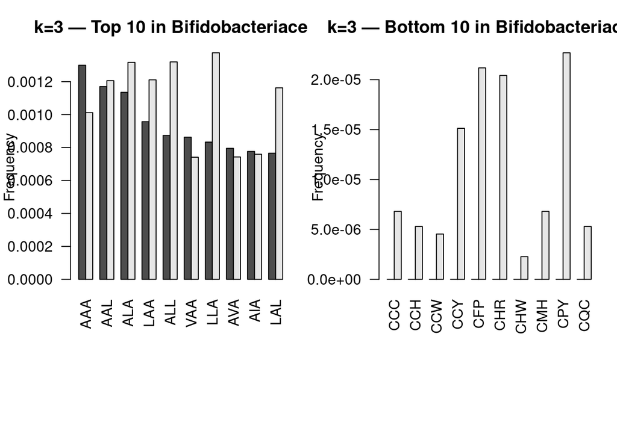

```r
# Analyze top/bottom 10 k-mers (k = 3–5)
analyze_k <- function(k) {
  freq_bifido <- aa_kmer_freq(prots_bifido, k)
  freq_ecoli  <- aa_kmer_freq(prots_ecoli, k)

  if (length(freq_bifido) == 0) return(invisible(NULL))

  top10    <- sort(freq_bifido, decreasing = TRUE)[1:min(10, sum(freq_bifido > 0))]
  bottom10 <- sort(freq_bifido, decreasing = FALSE)[1:min(10, length(freq_bifido))]

  comp_top <- rbind(Bifidobacteriaceae = freq_bifido[names(top10)],
                    `E. coli` = freq_ecoli[names(top10)])
  comp_bottom <- rbind(Bifidobacteriaceae = freq_bifido[names(bottom10)],
                       `E. coli` = freq_ecoli[names(bottom10)])

  op <- par(no.readonly = TRUE)
  par(mfrow = c(1,2), mar = c(9,4,3,1))
  barplot(comp_top, beside = TRUE, las = 2, ylab = "Frequency",
          main = paste0("k=", k, " — Top 10 in Bifidobacteriaceae"))
  barplot(comp_bottom, beside = TRUE, las = 2, ylab = "Frequency",
          main = paste0("k=", k, " — Bottom 10 in Bifidobacteriaceae"))
  par(op)

  invisible(list(k = k, top = top10, bottom = bottom10,
                 comp_top = comp_top, comp_bottom = comp_bottom))
}
# Run for k = 3, 4, 5
res_k3 <- analyze_k(3)
```

```r
res_k4 <- analyze_k(4)
```

[figure not shown]

```r
res_k5 <- analyze_k(5)
```

[figure not shown]

Answer: Some k-mers that are highly over-represented in Bifidobacteriaceae are rare in E. coli, and vice versa. These differences may reflect species-specific protein domains, repetitive motifs, secreted proteins, or metabolic adaptations. Overall, the k-mer composition highlights differences in proteome structure and function between the two organisms.